# ipsRdbs: Introduction to Probability, Statistics and R for Data-Based Sciences

Sujit K. Sahu

University of Southampton

S.K.Sahu@soton.ac.uk

April 10, 2024

#### Abstract

This is a vignette for the `R` package *ipsRdbs*. This package contains data sets, programmes and illustrations discussed in the book, “Introduction to Probability, Statistics & R: Foundations for Data-Based Sciences” by Sahu (2024).

#### Package

ipsRdbs 1.0.0

# 1 Introduction

This package complements the book, `Introduction to Probability, Statistics and R for Data-Based Sciences’ by Sahu (2024). The package distributes the data sets used in the book and provides code illustrating the statistical modeling of the data sets. In addition, the package provides code for illustrating various results in probability and statistics. For example, it provides code to simulate the Monty python game illustrating conditional probability, and gives simulation based examples to illustrate the central limit theorem and the weak law of large numbers. Thus the package helps a beginner reader in enhancing understanding of a few elementary concepts in probability and statistics, and introduces them to perform linear statistical modelling, i.e., regression and ANOVA which are among the key foundational concepts of data science and machine learning, more generally data-based sciences.

[figure not shown]

Figure 1: ipsRdbs book cover

## 1.1 Installing the required software packages

The reader is first instructed to install the `R` software package by searching for `CRAN` in the internet. The reader shoud then go onto the web-page https://cran.r-project.org/ and install the correct and latest version of the package on their own computer. Please note that `R` cannot be installed on a mobile phone. Once `R` has been installed, the next task is to install the frontend software package [Rstudio,](https://posit.co/download/rstudio-desktop/) which provides an easier interface to work with `R`.

After installing `R` and `Rstudio`, the reader should launch the `Rstudio` programme in their computer. This will open up a four pane window with one named ‘Console’ or ‘Terminal’. This window accepts commands (or our instructions) and prints results. For example, the reader may type 2+2 and then hit the Enter button to examine the result. The reader is asked to search the internet for gentler introductions and videos.

In order to getting started here, thereader is aked to install the add-on `R` package `ipsRdbs` simply by issuing the `R` command

```r
install.packages("ipsRdbs", dependencies=TRUE)
```

without committing any typing mistakes. If this installation is successful, the reader can issue the following two commands to list all `R` objects (data sets and programmes) included in the package.

```r
library(ipsRdbs)
ls("package:ipsRdbs")
```

Note that this command will only produce the intended results if only the package has been successfully installed in the first place.

## 1.2 How to learn more about the objects included in the package

All the listed objects, as the output of the `ls` command in the previous section, have associated help files. The reader can gain information for each of those object by asking for help by typing the question mark immediately followed by the object name, e.g. `?butterfly` or by issuing the command `help(butterfly)`.

The help files provide details about the objects and the user is able to run all the code included as illustrations at the end of the help file. This cam be done either by clicking the `Run Examples` link or simply by copy-pasting all the commands onto the command console in Rstudio. This is a great advantage of `R` as it allows the users to reproduce the results without having to learn all the commands and syntax correctly. After gaining this confidence, a beginner user can examine and experiment with the commands further. More details regarding the objects are provided in the book Sahu (2024).

The remainder of this vignette simply elaborates the help files for all the main objects and programmes included in the package. The main intention here is to enable the reader to reproduce all the results by actually running the commands and the code included already included in the help files.

Section 2 discusses all the data sets. All the `R` functions are discussed in 3.  
Some summary remarks are provided in Section 4.

# 2 Data sets

## 2.1 `beanie`: Age and value of beanie baby toys.

This data set contains the age and the value of 50 beanie baby toys. Source: Beanie world magazine. This data set has been used as an example of simple linear regression modellinhg where the exercise is to predict the value of a beanie baby toy by knowing it’s age.

```r
head(beanie)
```

```
#>      name age value
#> 1    Ally  52    55
#> 2   Batty  12    12
#> 3   Bongo  28    40
#> 4 Blackie  52    10
#> 5   Bucky  40    45
#> 6  Bumble  28   600
```

```r
summary(beanie)
```

```
#>      name                age            value
#>  Length:50          Min.   : 5.00   Min.   :  10.0
#>  Class :character   1st Qu.:12.00   1st Qu.:  15.0
#>  Mode  :character   Median :28.00   Median :  26.5
#>                     Mean   :26.52   Mean   : 128.9
#>                     3rd Qu.:40.00   3rd Qu.:  62.5
#>                     Max.   :64.00   Max.   :1900.0
```

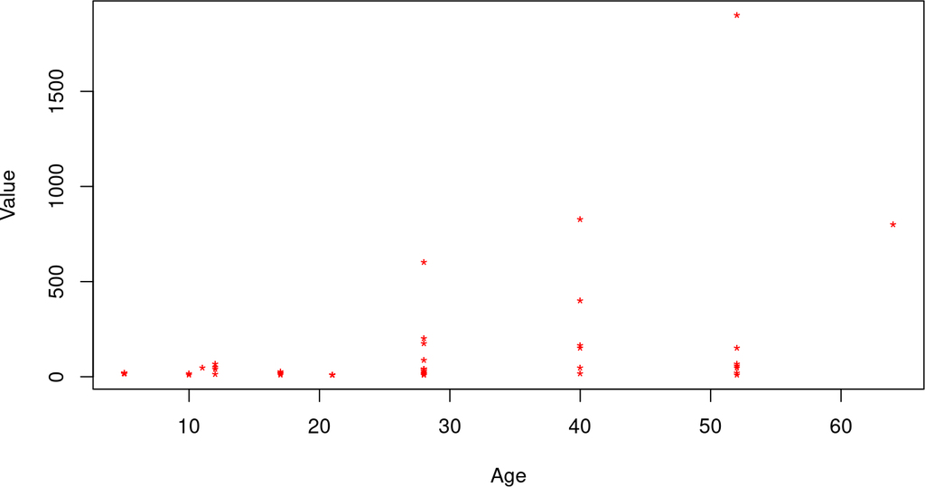

```r
plot(beanie$age, beanie$value, xlab="Age", ylab="Value", pch="*", col="red")
```

## 2.2 `bill`: Wealth and age of world billionaires

This data set contains wealth, age and region of 225 billionaires in 1992 as reported in the Fortune magazine. This data set can be used to illustrate exploratory data analysis by producing side-by-side box plots of wealth for billionaires from different continents of the world. It can also be used for multiple linear regression models, although such tasks have not been undertaken here.

```r
head(bill)
```

```
#>   wealth age region
#> 1   37.0  50      M
#> 2   24.0  88      U
#> 3   14.0  64      A
#> 4   13.0  63      U
#> 5   13.0  66      U
#> 6   11.7  72      E
```

```r
summary(bill)
```

```
#>      wealth            age         region
#>  Min.   : 1.000   Min.   :  7.00   A:37
#>  1st Qu.: 1.300   1st Qu.: 56.00   E:76
#>  Median : 1.800   Median : 65.00   M:22
#>  Mean   : 2.726   Mean   : 64.03   O:28
#>  3rd Qu.: 3.000   3rd Qu.: 72.00   U:62
#>  Max.   :37.000   Max.   :102.00
```

```r
table(bill$region)
```

```
#>
#>  A  E  M  O  U
#> 37 76 22 28 62
```

```r
levels(bill$region)
```

```
#> [1] "A" "E" "M" "O" "U"
```

```r
levels(bill$region) <- c("Asia", "Europe", "Mid-East", "Other", "USA")
bill.wealth.ge5 <- bill[bill$wealth>5, ]
bill.wealth.ge5
```

```
#>    wealth age   region
#> 1    37.0  50 Mid-East
#> 2    24.0  88      USA
#> 3    14.0  64     Asia
#> 4    13.0  63      USA
#> 5    13.0  66      USA
#> 6    11.7  72   Europe
#> 7    10.0  71 Mid-East
#> 8     8.2  77      USA
#> 9     8.1  68      USA
#> 10    7.2  66   Europe
#> 11    7.0  69 Mid-East
#> 12    6.2  36    Other
#> 13    5.9  49      USA
#> 14    5.3  73      USA
#> 15    5.2  52   Europe
```

```r
bill.region.A <-  bill[ bill$region == "A", ]
bill.region.A
```

```
#> [1] wealth age    region
#> <0 rows> (or 0-length row.names)
```

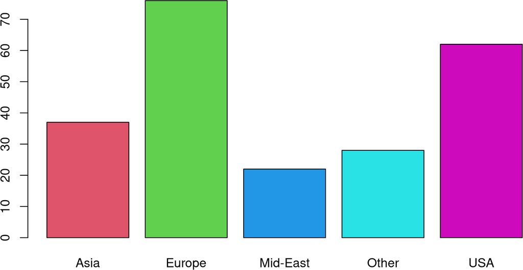

```r
a <-  seq(1, 10, by =2)
oddrows <- bill[a, ]
barplot(table(bill$region), col=2:6)
```

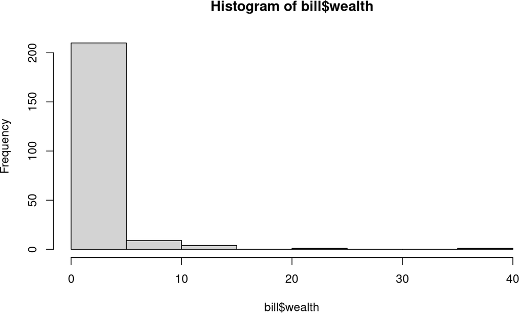

```r
hist(bill$wealth) # produces a dull looking plot
```

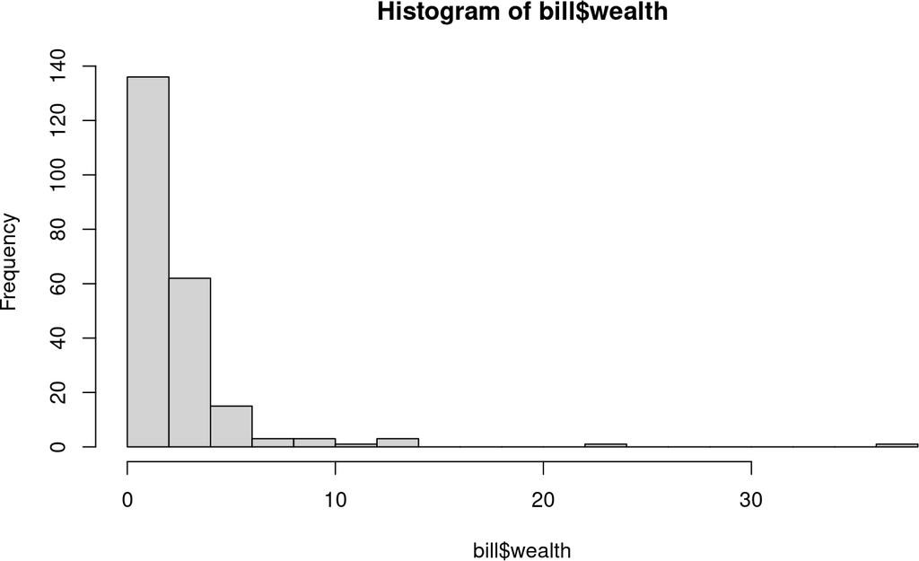

```r
hist(bill$wealth, nclass=20)  # produces a more detailed plot.
```

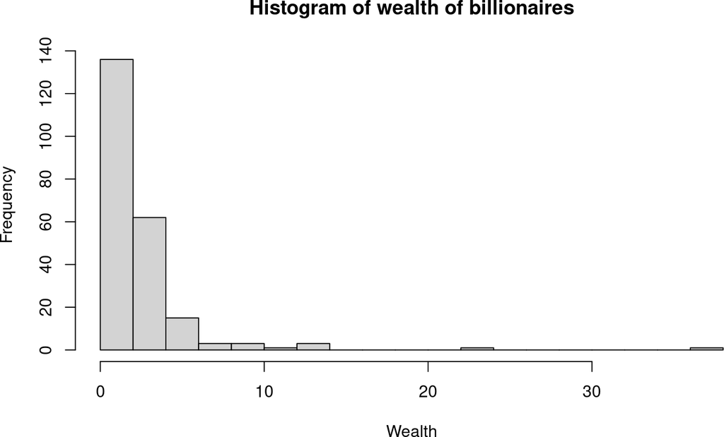

```r
hist(bill$wealth, nclass=20, xlab="Wealth",
     main="Histogram of wealth of billionaires")
```

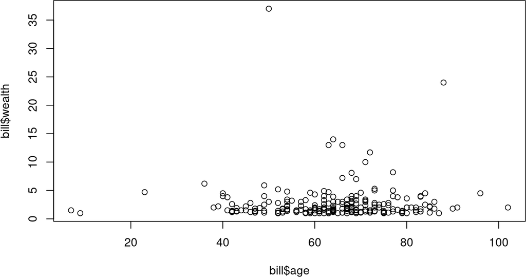

```r
plot(bill$age, bill$wealth)  # A very dull plot.
```

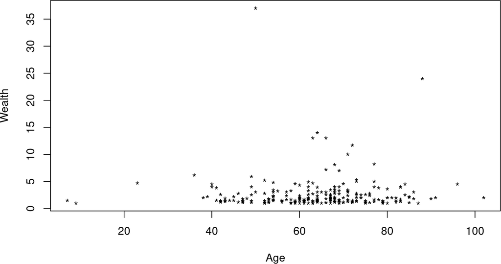

```r
plot(bill$age, bill$wealth, xlab="Age", ylab="Wealth", pch="*")  # better
```

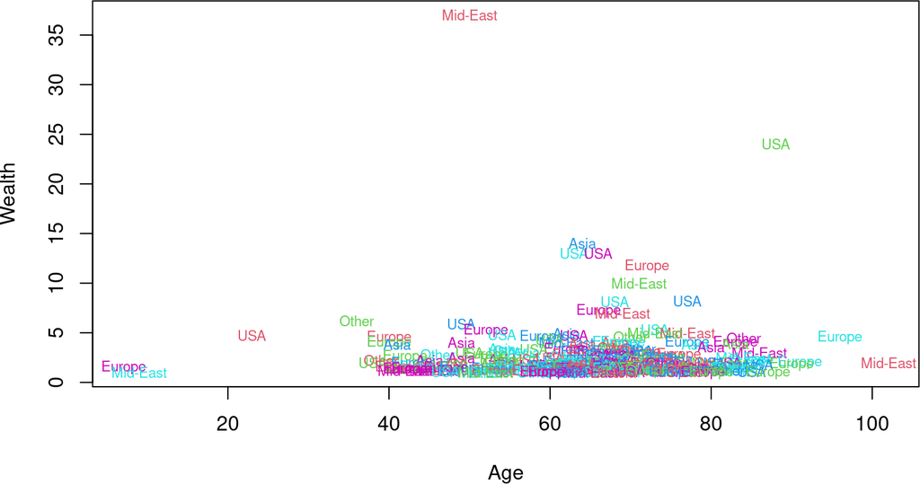

```r
plot(bill$age, bill$wealth, xlab="Age", ylab="Wealth", type="n")
# Lays the plot area but does not plot.
text(bill$age, bill$wealth, labels=bill$region, cex=0.7, col=2:6)
```

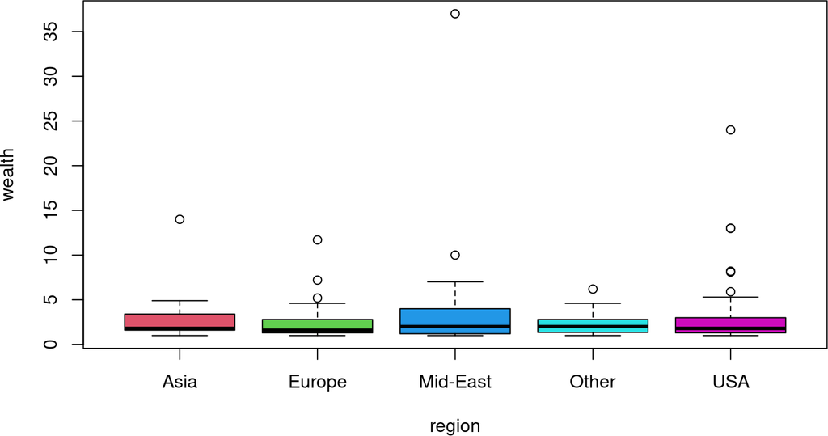

```r
# Adds the points to the empty plot.
# Provides a better looking plot with more information.
boxplot(data=bill, wealth ~ region, col=2:6)
```

```r
tapply(X=bill$wealth, INDEX=bill$region, FUN=mean)
```

```
#>     Asia   Europe Mid-East    Other      USA
#> 2.651351 2.257895 4.263636 2.278571 3.000000
```

```r
tapply(X=bill$wealth, INDEX=bill$region, FUN=sd)
```

```
#>     Asia   Europe Mid-East    Other      USA
#> 2.192617 1.623187 7.657150 1.265308 3.659974
```

```r
round(tapply(X=bill$wealth, INDEX=bill$region, FUN=mean), 2)
```

```
#>     Asia   Europe Mid-East    Other      USA
#>     2.65     2.26     4.26     2.28     3.00
```

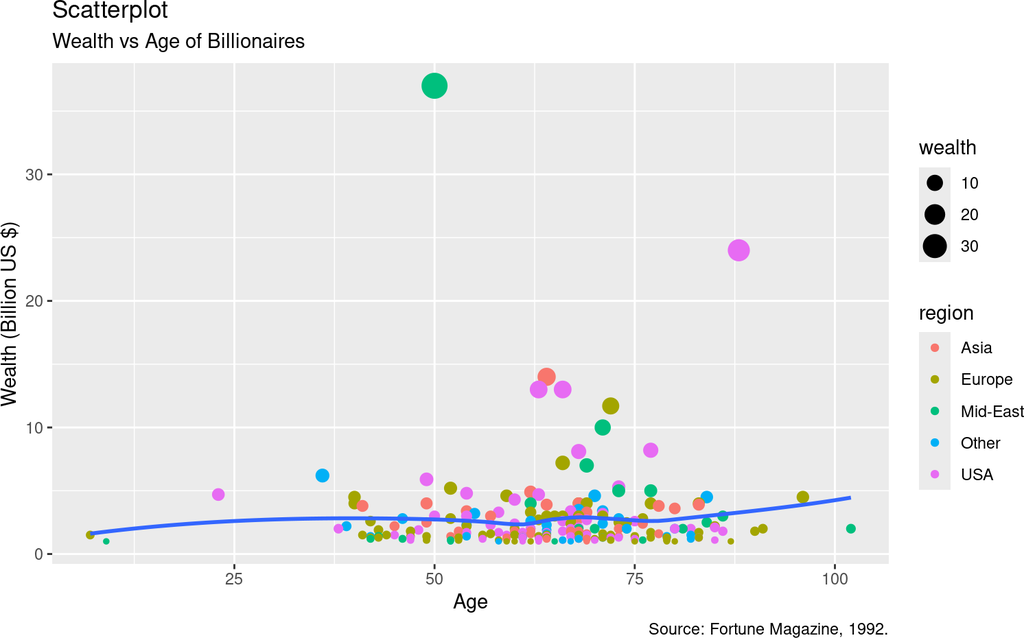

```r
library(ggplot2)
gg <- ggplot2::ggplot(data=bill, aes(x=age, y=wealth)) +
geom_point(aes(col=region, size=wealth)) +
geom_smooth(method="loess", se=FALSE) +
xlim(c(7, 102)) +
ylim(c(1, 37)) +
labs(subtitle="Wealth vs Age of Billionaires",
y="Wealth (Billion US $)", x="Age",
title="Scatterplot", caption = "Source: Fortune Magazine, 1992.")
plot(gg)
```

## 2.3 `bodyfat` : Body fat percentage and skinfold thickness of athletes

This data set contains body fat percentage data for 102 elite male athletes training at the Australian Institute of Sport. This data set has been used to illustrate simple linear regression in Chapter 17 of the book by Sahu (2024).

```r
summary(bodyfat)
```

```
#>     Skinfold         Bodyfat
#>  Min.   : 28.00   Min.   : 5.630
#>  1st Qu.: 37.52   1st Qu.: 6.968
#>  Median : 47.70   Median : 8.625
#>  Mean   : 51.42   Mean   : 9.251
#>  3rd Qu.: 58.15   3rd Qu.:10.010
#>  Max.   :113.50   Max.   :19.940
```

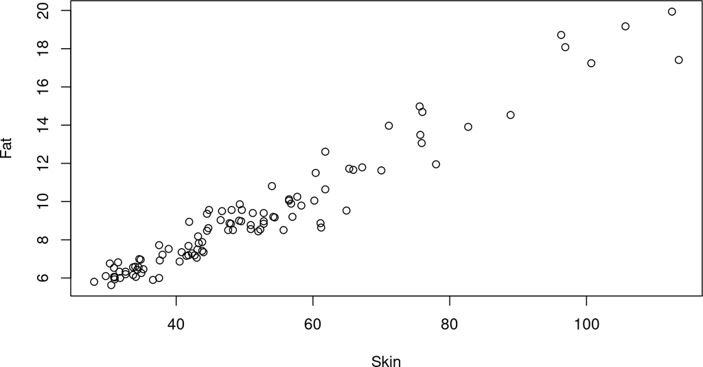

```r
plot(bodyfat$Skinfold,  bodyfat$Bodyfat, xlab="Skin", ylab="Fat")
```

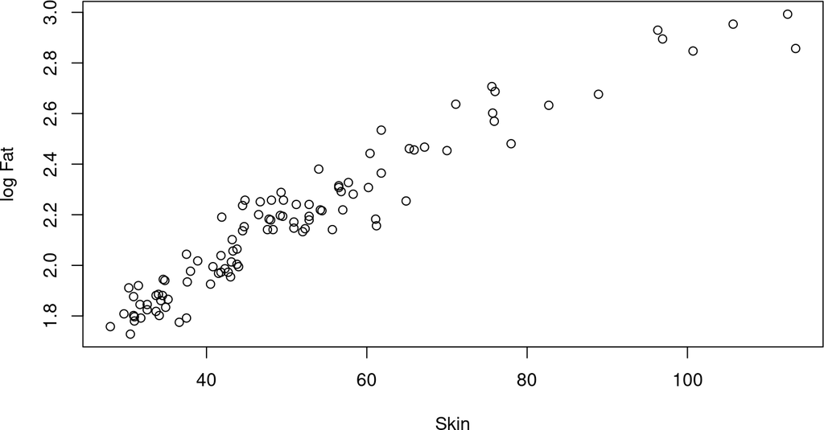

```r
plot(bodyfat$Skinfold,  log(bodyfat$Bodyfat), xlab="Skin", ylab="log Fat")
```

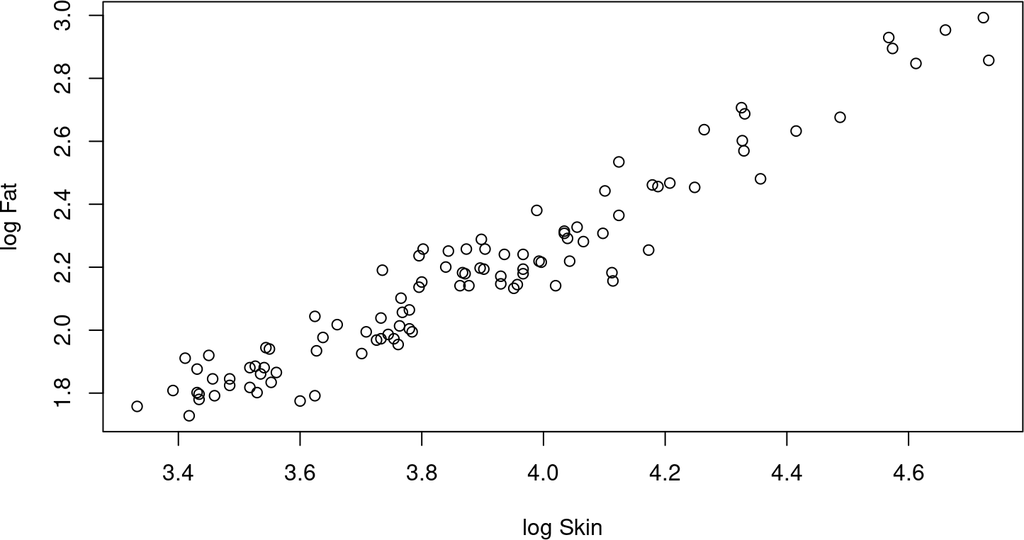

```r
plot(log(bodyfat$Skinfold),  log(bodyfat$Bodyfat), xlab="log Skin", ylab="log Fat")
```

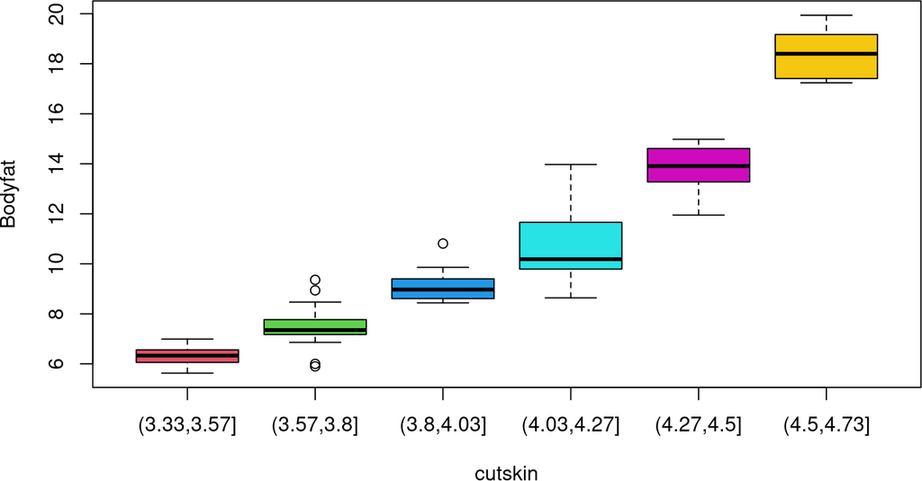

```r
# Keep the transformed variables in the data set
bodyfat$logskin <- log(bodyfat$Skinfold)
bodyfat$logbfat <- log(bodyfat$Bodyfat)
bodyfat$logskin <- log(bodyfat$Skinfold)
 # Create a grouped variable
bodyfat$cutskin <- cut(log(bodyfat$Skinfold), breaks=6)
boxplot(data=bodyfat, Bodyfat~cutskin, col=2:7)
```

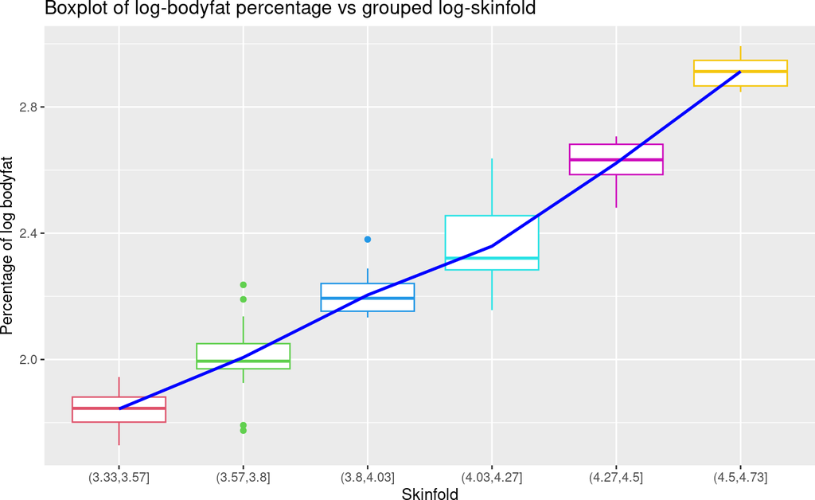

```r
require(ggplot2)
p2 <- ggplot(data=bodyfat, aes(x=cutskin, y=logbfat)) +
geom_boxplot(col=2:7) +
stat_summary(fun=mean, geom="line", aes(group=1), col="blue", linewidth=1) +
labs(x="Skinfold", y="Percentage of log bodyfat",
title="Boxplot of log-bodyfat percentage vs grouped log-skinfold")
plot(p2)
```

```r
n <- nrow(bodyfat)
x <- bodyfat$logskin
y <- bodyfat$logbfat
xbar <- mean(x)
ybar <- mean(y)
sx2 <- var(x)
sy2 <- var(y)
sxy <- cov(x, y)
r <- cor(x, y)
print(list(n=n, xbar=xbar, ybar=ybar, sx2=sx2, sy2=sy2, sxy=sxy, r=r))
```

```
#> $n
#> [1] 102
#>
#> $xbar
#> [1] 3.883108
#>
#> $ybar
#> [1] 2.175978
#>
#> $sx2
#> [1] 0.1084285
#>
#> $sy2
#> [1] 0.09106112
#>
#> $sxy
#> [1] 0.09566069
#>
#> $r
#> [1] 0.9627095
```

```r
hatbeta1 <- r * sqrt(sy2/sx2) # calculates estimate of the slope
hatbeta0 <- ybar - hatbeta1 * xbar # calculates estimate of the intercept
rs <-  y - hatbeta0 - hatbeta1 * x  # calculates residuals
s2 <- sum(rs^2)/(n-2)  # calculates estimate of sigma2
s2
```

```
#> [1] 0.006731453
```

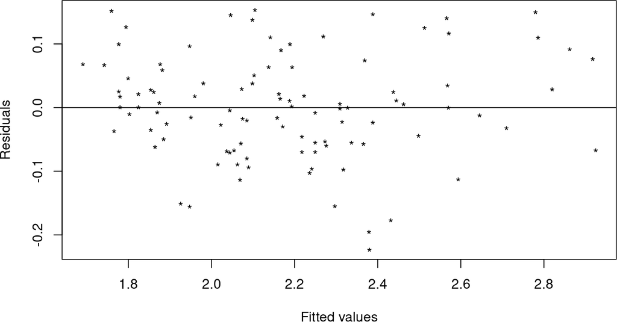

```r
bfat.lm <- lm(logbfat ~ logskin, data=bodyfat)
### Check the diagnostics
plot(bfat.lm$fit, bfat.lm$res, xlab="Fitted values", ylab = "Residuals", pch="*")
abline(h=0)
```

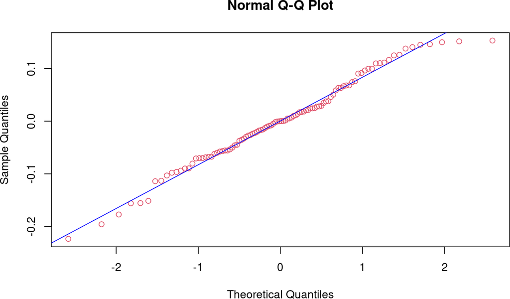

```r
### Should be a random scatter
qqnorm(bfat.lm$res, col=2)
qqline(bfat.lm$res, col="blue")
```

```r
# All Points should be on the straight line
summary(bfat.lm)
```

```
#>
#> Call:
#> lm(formula = logbfat ~ logskin, data = bodyfat)
#>
#> Residuals:
#>       Min        1Q    Median        3Q       Max
#> -0.223408 -0.055661  0.000052  0.056390  0.152984
#>
#> Coefficients:
#>             Estimate Std. Error t value Pr(>|t|)
#> (Intercept) -1.24988    0.09661  -12.94   <2e-16 ***
#> logskin      0.88225    0.02479   35.59   <2e-16 ***
#> ---
#> Signif. codes:  0 '***' 0.001 '**' 0.01 '*' 0.05 '.' 0.1 ' ' 1
#>
#> Residual standard error: 0.08205 on 100 degrees of freedom
#> Multiple R-squared:  0.9268, Adjusted R-squared:  0.9261
#> F-statistic:  1266 on 1 and 100 DF,  p-value: < 2.2e-16
```

```r
anova(bfat.lm)
```

```
#> Analysis of Variance Table
#>
#> Response: logbfat
#>            Df Sum Sq Mean Sq F value    Pr(>F)
#> logskin     1 8.5240  8.5240  1266.3 < 2.2e-16 ***
#> Residuals 100 0.6731  0.0067
#> ---
#> Signif. codes:  0 '***' 0.001 '**' 0.01 '*' 0.05 '.' 0.1 ' ' 1
```

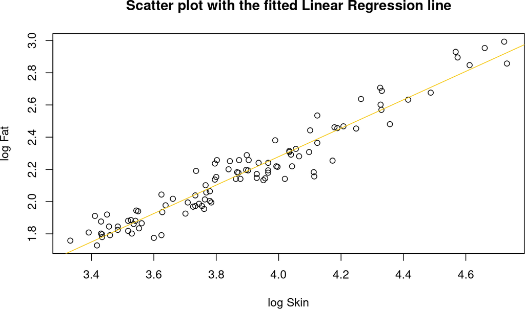

```r
plot(bodyfat$logskin,  bodyfat$logbfat, xlab="log Skin", ylab="log Fat")
abline(bfat.lm, col=7)
title("Scatter plot with the fitted Linear Regression line")
```

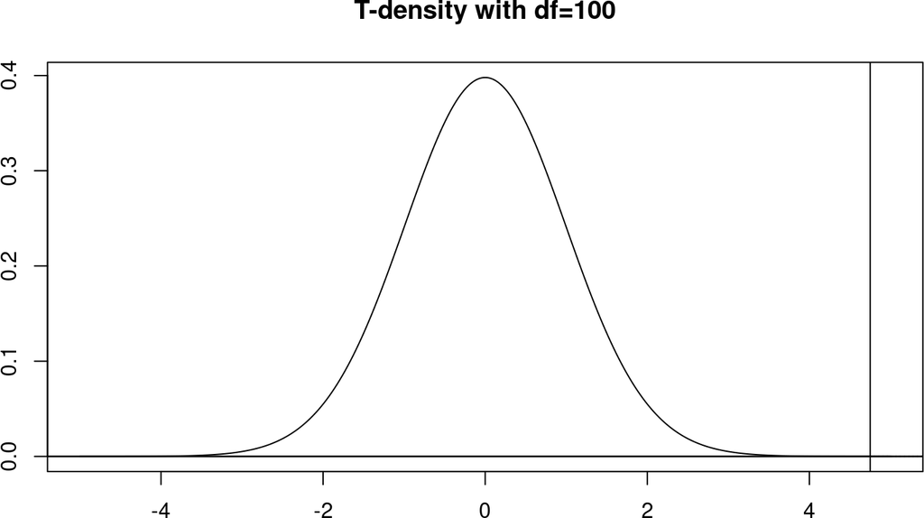

```r
# 95% CI for beta(1)
# 0.88225 + c(-1, 1) * qt(0.975, df=100) *  0.02479
# round(0.88225 + c(-1, 1) * qt(0.975, df=100) *  0.02479, 2)
# To test H0: beta1 = 1.
tstat <- (0.88225 -1)/0.02479
pval <- 2 * (1- pt(abs(tstat), df=100))
x <- seq(from=-5, to=5, length=500)
y <- dt(x, df=100)
plot(x, y,  xlab="", ylab="", type="l")
title("T-density with df=100")
abline(v=abs(tstat))
abline(h=0)
x1 <- seq(from=abs(tstat), to=10, length=100)
y1 <- rep(0, length=100)
x2 <- x1
y2 <- dt(x1, df=100)
segments(x1, y1, x2, y2)
abline(h=0)
```

```r
# Predict at a new value of Skinfold=70
# Create a new data set called new
newx <- data.frame(logskin=log(70))
a <- predict(bfat.lm, newdata=newx, se.fit=TRUE)
# Confidence interval for the mean of log bodyfat  at skinfold=70
a <- predict(bfat.lm, newdata=newx, interval="confidence")
# a
#          fit      lwr     upr
# [1,] 2.498339 2.474198 2.52248
# Prediction interval for a future log bodyfat  at skinfold=70
a <- predict(bfat.lm, newdata=newx, interval="prediction")
a
```

```
#>        fit      lwr      upr
#> 1 2.498339 2.333783 2.662895
```

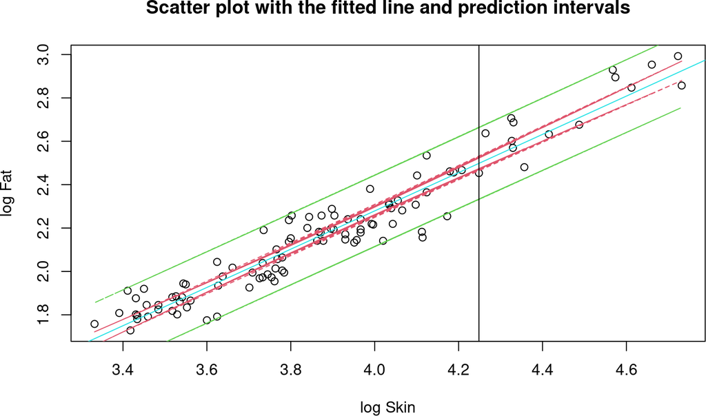

```r
#          fit      lwr      upr
# [1,] 2.498339 2.333783 2.662895
#prediction intervals for the mean
pred.bfat.clim <- predict(bfat.lm, data=bodyfat, interval="confidence")
#prediction intervals for future observation
pred.bfat.plim <- suppressWarnings(predict(bfat.lm, data=bodyfat, interval="prediction"))
plot(bodyfat$logskin,  bodyfat$logbfat, xlab="log Skin", ylab="log Fat")
abline(bfat.lm, col=5)
lines(log(bodyfat$Skinfold), pred.bfat.clim[,2], lty=2, col=2)
lines(log(bodyfat$Skinfold), pred.bfat.clim[,3], lty=2, col=2)
lines(log(bodyfat$Skinfold), pred.bfat.plim[,2], lty=4, col=3)
lines(log(bodyfat$Skinfold), pred.bfat.plim[,3], lty=4, col=3)
title("Scatter plot with the fitted line and prediction intervals")
symb <- c("Fitted line", "95% CI for mean", "95% CI for observation")
## legend(locator(1), legend = symb, lty = c(1, 2, 4), col = c(5, 2, 3))
# Shows where we predicted earlier
abline(v=log(70))
```

```r
summary(bfat.lm)
```

```
#>
#> Call:
#> lm(formula = logbfat ~ logskin, data = bodyfat)
#>
#> Residuals:
#>       Min        1Q    Median        3Q       Max
#> -0.223408 -0.055661  0.000052  0.056390  0.152984
#>
#> Coefficients:
#>             Estimate Std. Error t value Pr(>|t|)
#> (Intercept) -1.24988    0.09661  -12.94   <2e-16 ***
#> logskin      0.88225    0.02479   35.59   <2e-16 ***
#> ---
#> Signif. codes:  0 '***' 0.001 '**' 0.01 '*' 0.05 '.' 0.1 ' ' 1
#>
#> Residual standard error: 0.08205 on 100 degrees of freedom
#> Multiple R-squared:  0.9268, Adjusted R-squared:  0.9261
#> F-statistic:  1266 on 1 and 100 DF,  p-value: < 2.2e-16
```

```r
anova(bfat.lm)
```

```
#> Analysis of Variance Table
#>
#> Response: logbfat
#>            Df Sum Sq Mean Sq F value    Pr(>F)
#> logskin     1 8.5240  8.5240  1266.3 < 2.2e-16 ***
#> Residuals 100 0.6731  0.0067
#> ---
#> Signif. codes:  0 '***' 0.001 '**' 0.01 '*' 0.05 '.' 0.1 ' ' 1
```

## 2.4 `bombhits`: Number and frequency of bombhits in London

This data set contains the number of bomb hits in 576 areas in London during World War II. Data sourced from Shaw and Shaw (2019), see also Hand {} (1993). (David J. Hand and Ostrowski 1993) (Shaw and Shaw 2019) This data set has been used to illustrate elementary concepts of statistical inference in Chapter 9 of the book Sahu (2024).

```r
 summary(bombhits)
```

```
#>    numberhit         freq
#>  Min.   :0.00   Min.   :  1.0
#>  1st Qu.:1.25   1st Qu.: 14.0
#>  Median :2.50   Median : 64.0
#>  Mean   :2.50   Mean   : 96.0
#>  3rd Qu.:3.75   3rd Qu.:181.5
#>  Max.   :5.00   Max.   :229.0
```

```r
 # Create a vector of data
 x <- c(rep(0, 229), rep(1, 211), rep(2, 93), rep(3, 35), rep(4, 7), 5)
 y <- c(229, 211, 93, 35, 7, 1) # Frequencies
 rel_freq <- y/576
 xbar <- mean(x)
 pois_prob <- dpois(x=0:5, lambda=xbar)
 fit_freq <- pois_prob * 576
  #Check
  cbind(x=0:5, obs_freq=y, rel_freq =round(rel_freq, 4),
  Poisson_prob=round(pois_prob, 4), fit_freq=round(fit_freq, 1))
```

```
#>      x obs_freq rel_freq Poisson_prob fit_freq
#> [1,] 0      229   0.3976       0.3950    227.5
#> [2,] 1      211   0.3663       0.3669    211.3
#> [3,] 2       93   0.1615       0.1704     98.1
#> [4,] 3       35   0.0608       0.0528     30.4
#> [5,] 4        7   0.0122       0.0122      7.1
#> [6,] 5        1   0.0017       0.0023      1.3
```

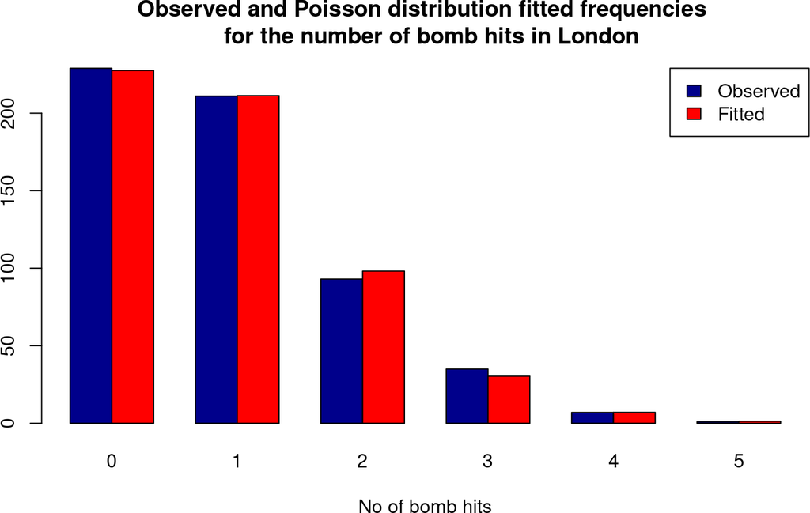

```r
  obs_freq <- y
  xuniques <- 0:5
  a <- data.frame(xuniques=0:5, obs_freq =y, fit_freq=fit_freq)
  barplot(rbind(obs_freq, fit_freq),
  args.legend = list(x = "topright"),
  xlab="No of bomb hits",
  names.arg = xuniques,  beside=TRUE,
  col=c("darkblue","red"),
  legend =c("Observed", "Fitted"),
  main="Observed and Poisson distribution fitted frequencies
  for the number of bomb hits in London")
```

## 2.5 `cement`: Breaking strength of cement

Contains data regarding breaking strength of cement. This data set has been used to illustrate analysis of variance in Chapter 19 of the book Sahu (2024).

```r
summary(cement)
```

```
#>     strength        gauger     breaker
#>  Min.   :4160   Min.   :1   Min.   :1
#>  1st Qu.:4660   1st Qu.:1   1st Qu.:1
#>  Median :5100   Median :2   Median :2
#>  Mean   :5118   Mean   :2   Mean   :2
#>  3rd Qu.:5565   3rd Qu.:3   3rd Qu.:3
#>  Max.   :6200   Max.   :3   Max.   :3
```

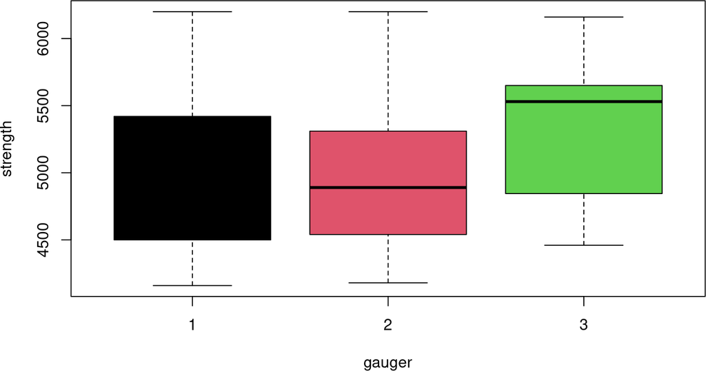

```r
boxplot(data=cement, strength~gauger, col=1:3)
```

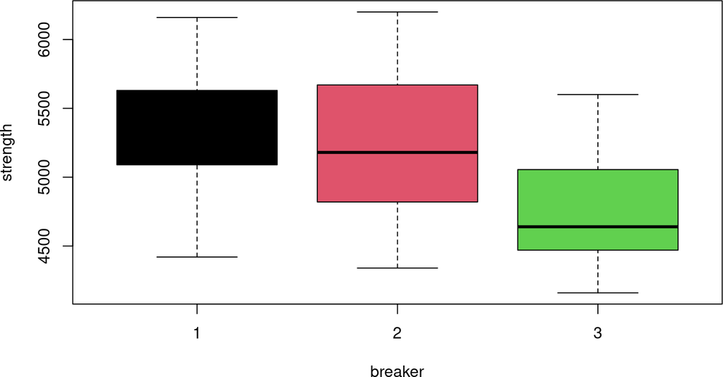

```r
boxplot(data=cement, strength~breaker, col=1:3)
```

## 2.6 `cfail`: Number of weekly computer failures

This data set contains weekly number of failures of a university computer system over a period of two years. Source: Hand {} (1993). (David J. Hand and Ostrowski 1993) Like the `bombhits` example this data set has been used to illustrate elementary concepts of statistical inference in Chapter 9 of the book Sahu (2024).

## 2.7 `cheese` : Taste of cheese

This data set is from a testing of cheese experiment. This data set has been used to illustrate multiple linear regression modeling in Chapter 18 of the book Sahu (2024).

```r
summary(cheese)
```

```
#>      Taste         AceticAcid          H2S             LacticAcid        logH2S
#>  Min.   : 0.70   Min.   : 87.97   Min.   :   20.01   Min.   :0.860   Min.   : 2.996
#>  1st Qu.:13.55   1st Qu.:188.20   1st Qu.:   53.74   1st Qu.:1.250   1st Qu.: 3.977
#>  Median :20.95   Median :227.03   Median :  207.46   Median :1.450   Median : 5.329
#>  Mean   :24.53   Mean   :284.18   Mean   : 2702.98   Mean   :1.442   Mean   : 5.942
#>  3rd Qu.:36.70   3rd Qu.:358.84   3rd Qu.: 1950.35   3rd Qu.:1.667   3rd Qu.: 7.575
#>  Max.   :57.20   Max.   :637.78   Max.   :26876.31   Max.   :2.010   Max.   :10.199
```

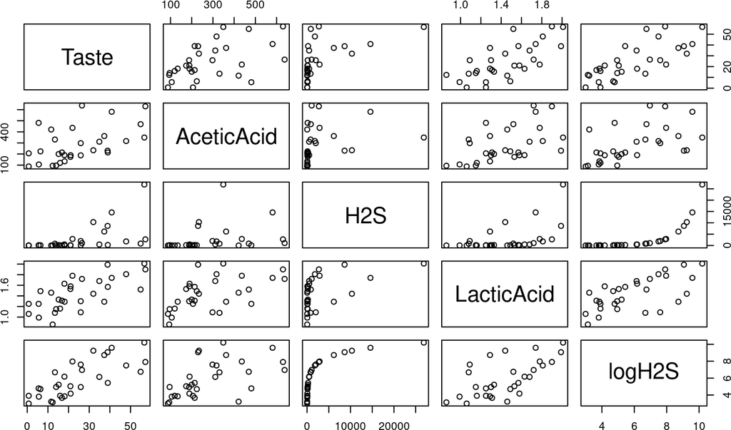

```r
pairs(cheese)
```

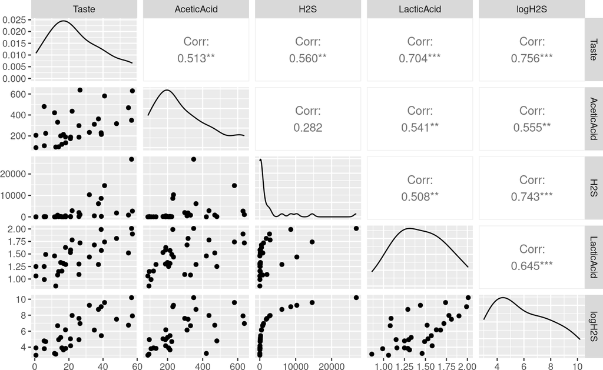

```r
GGally::ggpairs(data=cheese)
```

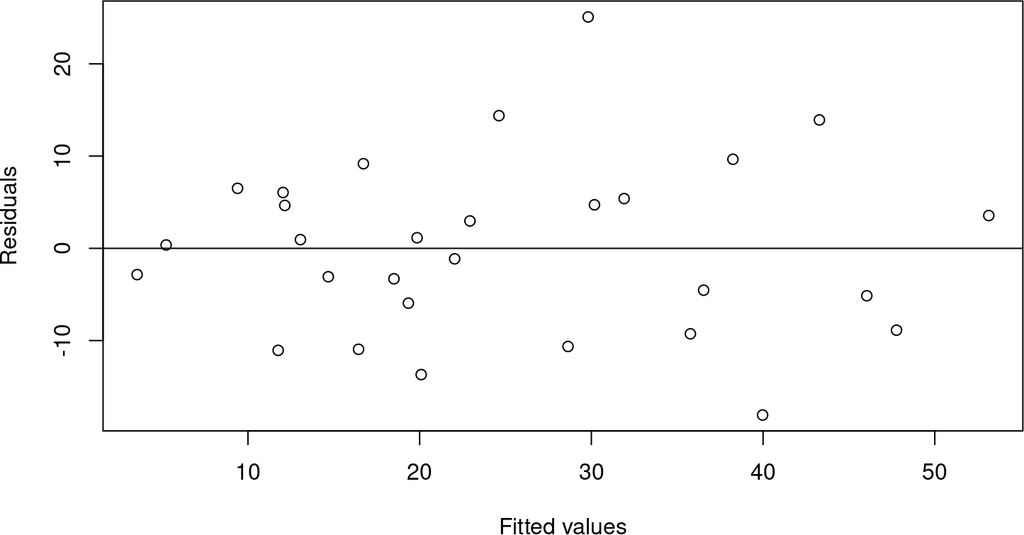

```r
cheese.lm <- lm(Taste ~ AceticAcid +  LacticAcid + logH2S, data=cheese, subset=2:30)
 # Check the diagnostics
 plot(cheese.lm$fit, cheese.lm$res, xlab="Fitted values", ylab = "Residuals")
 abline(h=0)
```

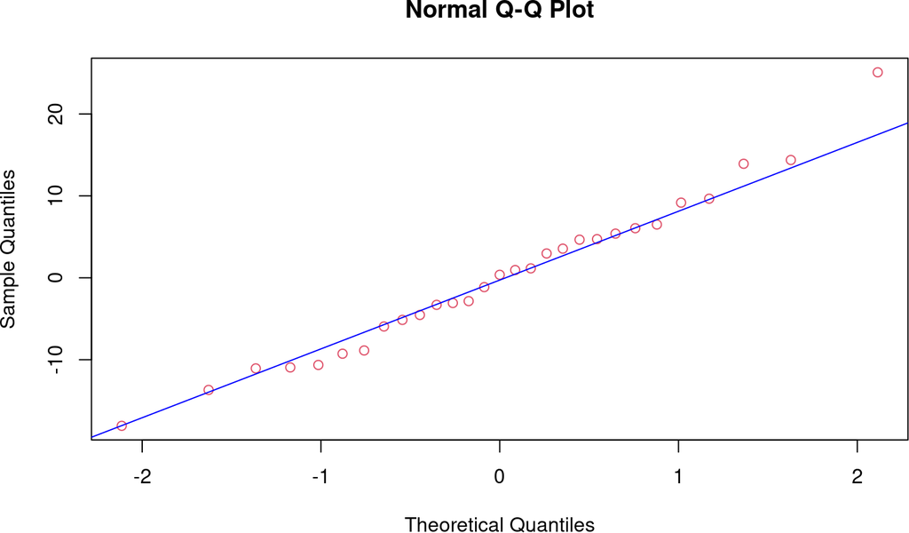

```r
 # Should be a random scatter
 qqnorm(cheese.lm$res, col=2)
 qqline(cheese.lm$res, col="blue")
```

```r
 summary(cheese.lm)
```

```
#>
#> Call:
#> lm(formula = Taste ~ AceticAcid + LacticAcid + logH2S, data = cheese,
#>     subset = 2:30)
#>
#> Residuals:
#>      Min       1Q   Median       3Q      Max
#> -18.0718  -5.9432   0.3657   5.3919  25.0876
#>
#> Coefficients:
#>              Estimate Std. Error t value Pr(>|t|)
#> (Intercept) -31.41789    9.95702  -3.155  0.00414 **
#> AceticAcid    0.00478    0.01484   0.322  0.74997
#> LacticAcid   21.70560    8.69079   2.498  0.01945 *
#> logH2S        3.84994    1.21284   3.174  0.00396 **
#> ---
#> Signif. codes:  0 '***' 0.001 '**' 0.01 '*' 0.05 '.' 0.1 ' ' 1
#>
#> Residual standard error: 10.06 on 25 degrees of freedom
#> Multiple R-squared:  0.6631, Adjusted R-squared:  0.6227
#> F-statistic:  16.4 on 3 and 25 DF,  p-value: 4.222e-06
```

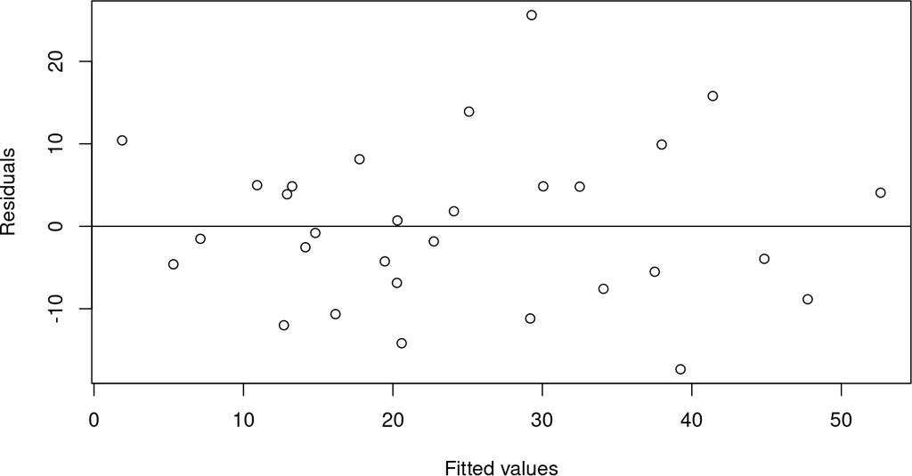

```r
 cheese.lm2 <- lm(Taste ~ LacticAcid + logH2S, data=cheese)
 # Check the diagnostics
 plot(cheese.lm2$fit, cheese.lm2$res, xlab="Fitted values", ylab = "Residuals")
 abline(h=0)
```

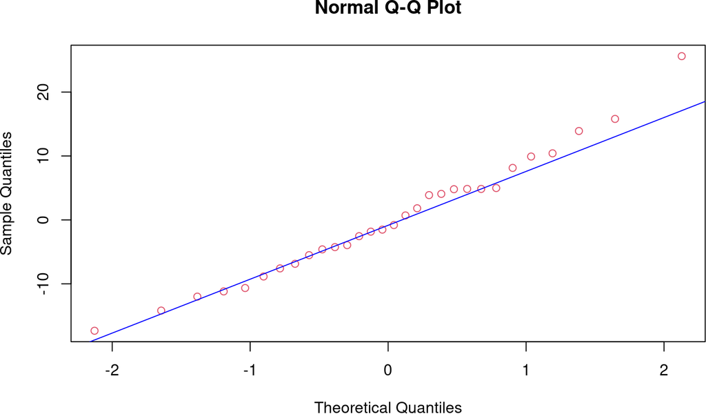

```r
 qqnorm(cheese.lm2$res, col=2)
 qqline(cheese.lm2$res, col="blue")
```

```r
 summary(cheese.lm2)
```

```
#>
#> Call:
#> lm(formula = Taste ~ LacticAcid + logH2S, data = cheese)
#>
#> Residuals:
#>     Min      1Q  Median      3Q     Max
#> -17.343  -6.529  -1.164   4.844  25.618
#>
#> Coefficients:
#>             Estimate Std. Error t value Pr(>|t|)
#> (Intercept)  -27.592      8.982  -3.072  0.00481 **
#> LacticAcid    19.888      7.959   2.499  0.01885 *
#> logH2S         3.946      1.136   3.475  0.00174 **
#> ---
#> Signif. codes:  0 '***' 0.001 '**' 0.01 '*' 0.05 '.' 0.1 ' ' 1
#>
#> Residual standard error: 9.942 on 27 degrees of freedom
#> Multiple R-squared:  0.6517, Adjusted R-squared:  0.6259
#> F-statistic: 25.26 on 2 and 27 DF,  p-value: 6.552e-07
```

```r
 # How can we predict?
 newcheese <- data.frame(AceticAcid = 300, LacticAcid = 1.5, logH2S=4)
 cheese.pred <- predict(cheese.lm2, newdata=newcheese, se.fit=TRUE)
 cheese.pred
```

```
#> $fit
#>        1
#> 18.02409
#>
#> $se.fit
#> [1] 3.111924
#>
#> $df
#> [1] 27
#>
#> $residual.scale
#> [1] 9.942372
```

```r
 # Obtain confidence interval
 cheese.pred$fit + c(-1, 1) * qt(0.975, df=27) * cheese.pred$se.fit
```

```
#> [1] 11.63895 24.40923
```

```r
 # Using R to predict
 cheese.pred.conf.limits <- predict(cheese.lm2, newdata=newcheese, interval="confidence")
 cheese.pred.conf.limits
```

```
#>        fit      lwr      upr
#> 1 18.02409 11.63895 24.40923
```

```r
 # How to find prediction interval
 cheese.pred.pred.limits <- predict(cheese.lm2, newdata=newcheese, interval="prediction")
 cheese.pred.pred.limits
```

```
#>        fit       lwr      upr
#> 1 18.02409 -3.351891 39.40007
```